# README

**REQUIRED** — An API Key is required to use this module.

Follow the steps below to learn how to generate an API Key and enter it into the YouTube module.

## Steps to finish setup

- Login into Google Developer API Console
- Create a Project
- Enable the YouTube API
- Creating the API Credentials
- Enter your API Key into the YouTube module.

## What is an API Key and why do I need it?

> An application programming interface key(API key) is a code passed in by computer programs calling an application programming interface (API) to identify the calling program, its developer, or its user to the Web site.

An API Key allows the YouTube module access to the data stored on the YouTube API which allows us to look up information about YouTube Channels and Videos.

## Logging into the Google Developer API Console

- Click the following link to open the [Google Developer API Console](https://console.developers.google.com/apis/dashboard)
- You may be asked to sign in
  - Follow the on screen steps to sign in with your Google account.
- Continue to the next step to create a new project.

## Creating a new Project

**NOTE** — If you already have a project you may activate the YouTube API on that one instead of creating a new one. If you do not know if you have a project, follow the steps below to create one.

After signing in you will be presented with the following screen:

[figure not shown]

- Locate and Click the `Create Project` button. You may be presented with the following screen, if so click the `Create` to continue button.

[figure not shown]

- Once the next section loads enter `Infinity Dashboard Module` as the `Project Name`
- Click the `Create` button to continue.

[figure not shown]

- You will the be redirected to the project’s dashboard.
- Click the `+ Enable APIs and services` button to continue to the next step.

[figure not shown]

## Enabling the YouTube API

You will be redirected to a page that looks like the following:

[figure not shown]

- Click the `Search for APIs & Services` text field
- Enter `YouTube Data API v3`
- Click the resulting tile to continue to the next section.

[figure not shown]

- You will be redirected to a page that looks like the following:

[figure not shown]

- Locate and click the `Enable` button
- The API will then be enabled after a few moments
- Once the API is created continue to the next section

## Creating API Credentials

After the API is enabled you will then be redirected to the API’s dashboard page. Before you’ll be able to use this API you’ll need to create the credentials for it.

[figure not shown]

- Click the `Create Credentials` button
- Click the `API Key` link shown in the screenshot below:

[figure not shown]

- You will be brought to the following page:

[figure not shown]

- Enter a name for the API Key you’re creating such as `Infinity Dashboard YouTube Module`
- Select the `None` option in the `Application restrictions` section
- Click the `API Restrictions` tab
- Select the `YouTube Data API v3` option in the dropdown.

[figure not shown]

- Click the `Create` button to continue.
- A popup will appear with that contains your newly created API Key.
- Copy the revealed API Key by performing a `Right Click` and selecting the `Copy` action
- Click the `Close` button and continue to the next section.

[figure not shown]

## Entering your API Key into Infinity Dashboard

- Open Infinity Dashboard.app
- Click on the ‘Module Config’ item in the sidebar
- Locate the YouTube module you want to configure
- Click the Pencil icon to open the module configuration
- Locate the **YouTube API Key** config option
- Click the **Your YouTube API Key** label to edit this value.
- Paste the copied API Key into the field.

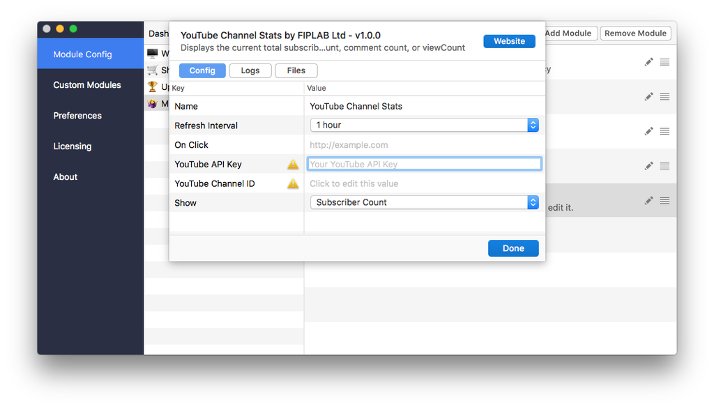

**Tip** — You can reuse this API Key for multiple modules. You can `Right Click` the module in the list and select the `Duplicate` option to copy it and *ALL* of it’s configuration into a new module.

**Success** — You’re All Set!